# Predi-Pitch: Snack on This Curve Whenever You Want

David Scolari, Harrison Snell, Brandon Williams

4/13/2022

## Introduction

Hitting a baseball has been shown to be one of the most difficult tasks in all of sports. Anybody who has gone to a batting cage and tried the fastest machine for fun knows how hard it can be to hit a normal fastball. That does not even include the possibilities of breaking balls and off-speed pitches. Batters have a fraction of a fraction of a second to recognize a pitch, determine if that pitch will be a ball or a strike, and set their swing into motion. Considering the human body can only move so fast to get the bat over the plate, the batter has to make their decision moments after the ball leaves the pitcher’s hand. At that point, even some professional baseball players have to guess on whether they are facing a changeup or a fastball or a curveball. Any additional information the batter can have is crucial. The goal of our model is to provide some of that additional information.

Pitch predicting is a very important part of baseball. So important that teams will do almost anything for insight on what the opposing team’s pitcher is going to throw. Other than illicit methods, hitters are trained to use information on a pitcher’s previous pitch throwing behvior to guess which pitch is coming next. We can model this deciscion making process with machine learning techniques.

By modeling pitch prediction, we can learn what information is relevant to a pitcher’s pitch selection. We can also better understand what makes a pitcher more unpredictable than other. It’s gonna be good

In the following report will talk about why pitches are different, share evidence that pitchers have different strategies from at bat to at bat, and describe the engineering of our model, which is basically a trashcan .

## Why do we care about a pitch?

Not all pitches are made the same. From sliders to cutters to knuckleballs, each pitch tends to have its own characteristics that define it.

| pitch_type | px | pz | start_speed | end_speed | spin_rate | spin_dir | break_angle | break_length | break_y |
| --- | --- | --- | --- | --- | --- | --- | --- | --- | --- |
| CH | -0.2004531 | 1.859088 | 85.81363 | 79.19324 | 1734.5396 | 212.37185 | 8.859414 | 7.694970 | 23.82537 |
| CU | 0.0756174 | 1.802014 | 78.16450 | 72.29356 | 1446.6248 | 89.21560 | -9.948970 | 12.569182 | 23.83973 |
| EP | 0.1831130 | 2.022092 | 66.51596 | 61.32254 | 1381.7363 | 44.09603 | -9.033333 | 16.907512 | 23.85540 |
| FA | -0.1840000 | 1.768333 | 88.90000 | 80.60000 | 2448.7507 | 148.70967 | -7.066667 | 7.500000 | 23.70000 |
| FC | 0.2211626 | 2.310223 | 88.54320 | 81.99196 | 1018.4097 | 164.45461 | -5.357321 | 6.093412 | 23.85148 |
| FF | 0.0071570 | 2.638026 | 93.62794 | 85.90142 | 2175.7277 | 193.63051 | 13.491285 | 3.721318 | 23.79359 |
| FS | -0.3771798 | 1.915900 | 84.56765 | 78.60294 | 1483.1980 | 222.07379 | 17.104412 | 6.652941 | 23.85882 |
| FT | -0.0227988 | 2.351487 | 92.15093 | 84.67758 | 2129.6691 | 169.48873 | -5.557804 | 5.749812 | 23.80294 |
| KC | 0.0839310 | 1.709555 | 81.50706 | 75.23154 | 1318.3440 | 89.54775 | -6.516319 | 11.551069 | 23.82959 |
| PO | 0.9680839 | 4.114041 | 86.21714 | 79.08000 | 1928.4078 | 210.20437 | 21.037143 | 5.171429 | 23.79143 |
| SI | -0.1321975 | 2.309338 | 92.81275 | 85.41892 | 2008.5825 | 216.36221 | 21.267940 | 5.879977 | 23.80938 |
| SL | 0.2318519 | 1.866506 | 85.58814 | 79.35203 | 901.0771 | 162.50623 | -3.270639 | 8.079149 | 23.85377 |
| UN | 3.4876667 | 3.531333 | 41.86667 | 39.80000 | 823.2617 | 218.88567 | -1.166667 | 31.800000 | 23.96667 |

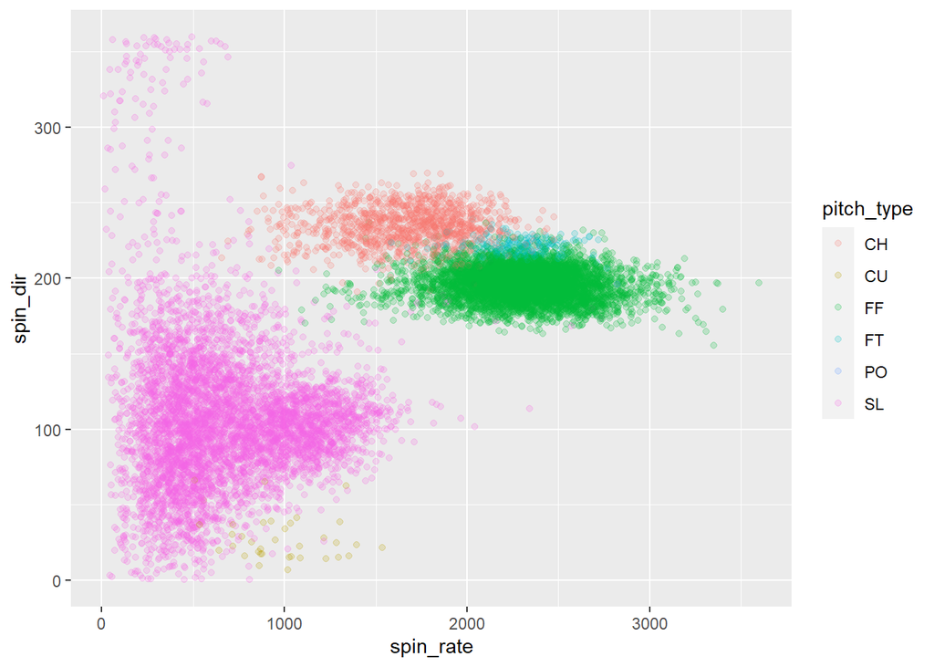

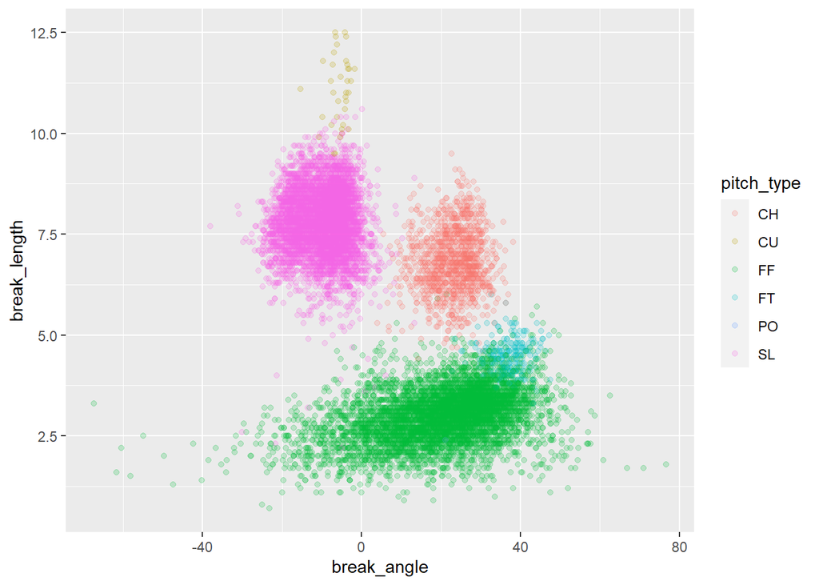

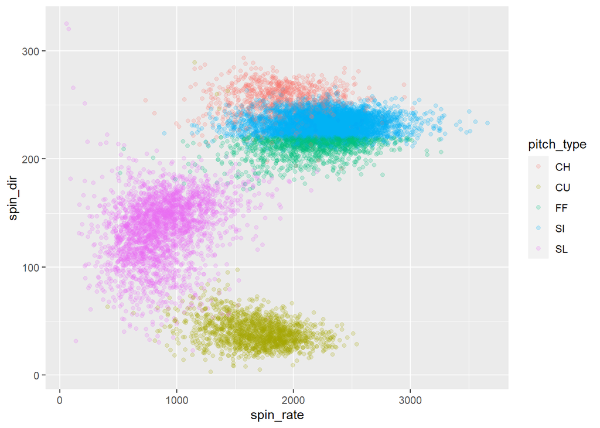

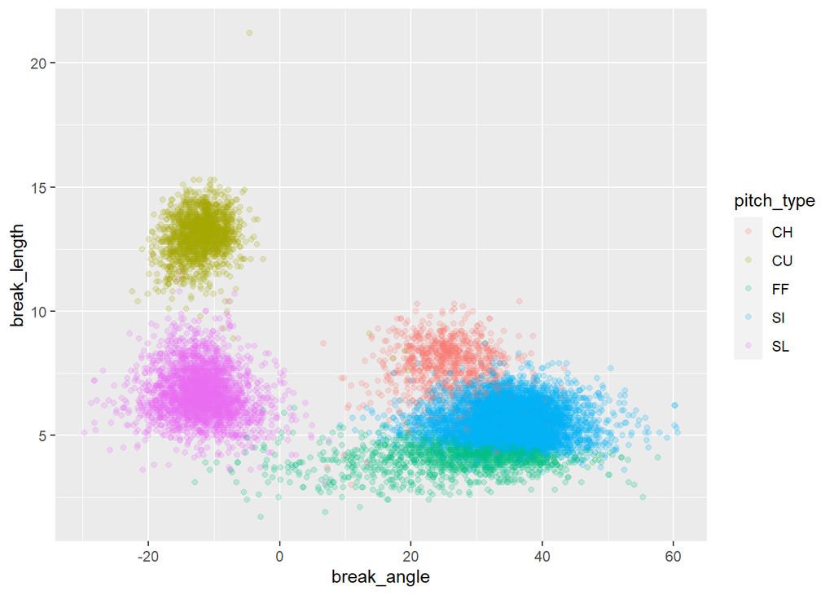

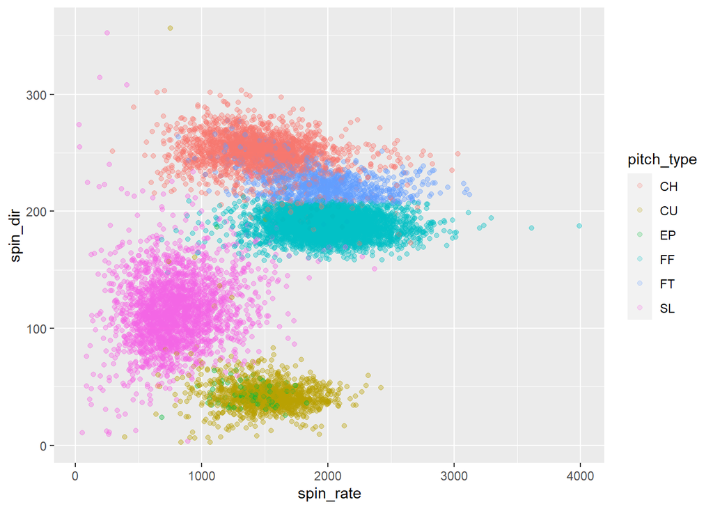

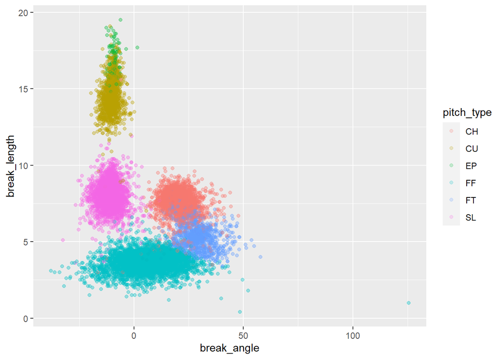

So to some degree we have established that each pitch has a unique set of characteristics for the most part. However, this set of characteristics is also unique to each pitcher.

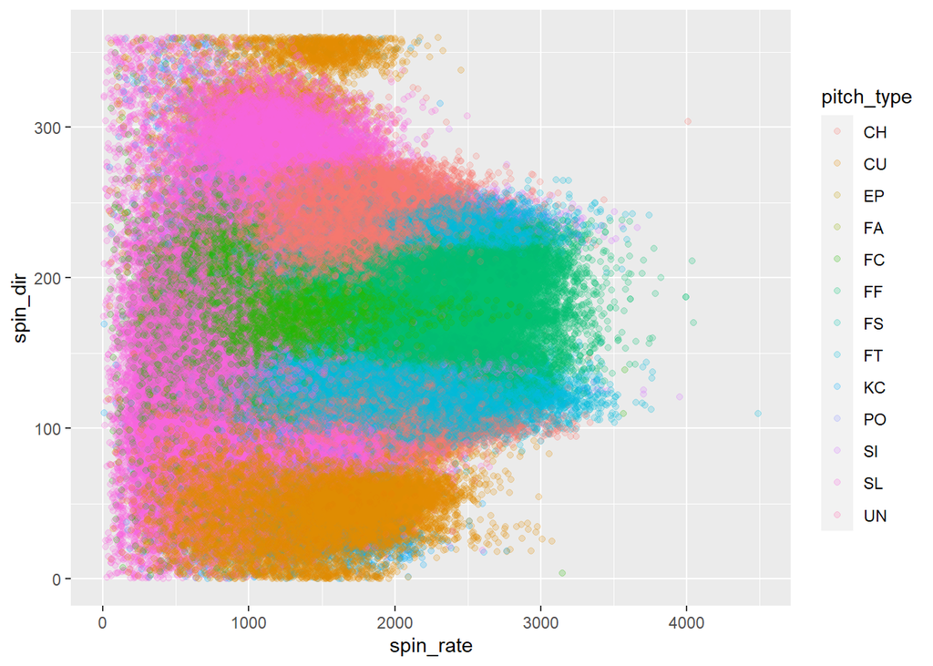

## Our Random Forrest

### Methodology

The models are generated with a train/test split and then evaluated for the out-of-sample performance against the testing set. Models are generated per pitcher, in such a way that be beneficial in application to a baseball manager or hitter, given the situation in the game.

#### The Situational Model

The first of our three random forest models uses information readily available in the at-bat to predict the upcoming pitch. The features involved here include the ball-strike count, opposing batter’s stance, inning, how many pitches thrown in the at-bat so far, the game score, and the runners on base. This is the most interpretable model, as it is composed of the factors that are generally considered most relevant and well-known by players and coaches in the moment. As random forests are an aggregation of individual trees, it can be illustrative to look at a single tree to get a sense for how decisions are being made at various nodes. Consider, for example, the following tree as an example of what the random forest is doing for pitcher Felix Hernandez.

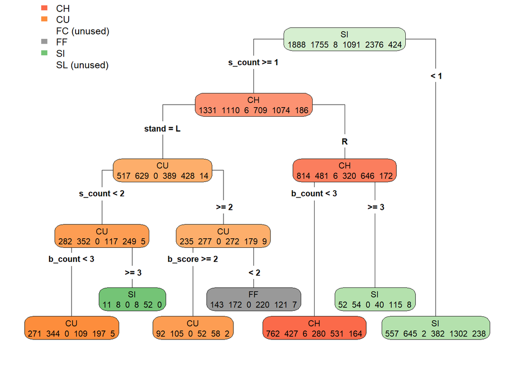

Hernandez is a pitcher with a diverse arsenal of pitches. As one can see, the predictive model analyzes factors about the game situation to indicate the next pitch. It considers, for example, the count on the batter and whether the batter stands left or right. After running through the branches and nodes with binary decisions based on the in-game situation, a prediction about the next pitch is made at the bottom of the tree. The random forest takes a bootstrap aggregate of trees like this one, but a single tree helps us see an example of the predictive process.

#### The Lagged Model

The second random forest builds upon the features selected in the Situational Model and supplements them with information about the previous two pitches and the event the last at-bat. This allows for the model to incorporate lagged information that might directly influence the next pitch. Did the pitcher just give up a home run on the curve? Maybe it’s a steady diet of fastballs from here on out. Did the pitcher just give the batter two straight fastballs to study? Perhaps it’s time for an off-speed pitch like a change-up.

#### Trash Can Model

The third and final random forest uses nearly every feature from the dataset to control for all possible scenarios and variations in the feature matrix. This means that it not only considers all the factors included in the other two models, but also includes what the pitcher’s game has looked like so far; that is, it takes into account the pitch choices as a percent of the overall pitches in the game up to that point. (Is this a correct reading?) So if the pitcher is leaning heavily on the slider that day, this model will incorporate that pattern.

## Results

To measure our models’ effectiveness, we compare them to the most-common pitch thrown by the pitcher (called “sitONE”) and to each other. The out-of-sample performance of each model is presented in “trashcans” 1 to 3 (our sincerest apologies to Astros fans for the name).

On the other hand, some pitcher profiles grew in accuracy only up through the first or second model, and then decrease as more features are added. For example, Mark Melancon and Huston Street have out-of-sample prediction accuracies that peak in the Lagged Model but fall in the Game Fixed Effects Model. We present this as some evidence of over-fitting for certain pitchers.

Not all pitchers are particularly predictable, however. Corey Kluber, a two-time Cy Young winner (one time in our data window), has such a varied arsenal of pitches that even the most predictive model (.343 out of sample accuracy) barely little information about the next pitch, even if it beats he sit-one rate. Further, some pitchers remained elusive for all three of the models. Trevor Rosenthal, for instance, throws a fastball on 75% of his pitches, and all three models performed worse than this “sitting on the pitch” rate. [Do we have a good reason for why this might be happening?]

Finally, we note that predictive power does not necessarily equate to hits. Enter Zack Britton, who led the league in saves during the 2016 season. Britton is nearly a one-pitch pitcher, throwing sinkers on 89.7% of his pitches. The Game Fixed Effects model improves this prediction a few fractions of a percent, but in either case, it’s fair to say that most hitters know exactly what Britton is about to throw. Nevertheless, Britton put up an otherworldly 0.54 ERA in 2016! That is to say, even if batters knew with near perfect clairvoyance a that sinker was on its way, making contact that leads to a hit is a whole other matter.

## Appendix

Overall Performance

| pitcher_last | pitcher_first | rate_sitONE | rate_trashcan1 | rate_trashcan2 | rate_trashcan3 |
| --- | --- | --- | --- | --- | --- |
| Archer | Chris | 0.474 | 0.559 | 0.580 | 0.566 |
| Arrieta | Jake | 0.471 | 0.474 | 0.477 | 0.470 |
| Boxberger | Brad | 0.631 | 0.644 | 0.651 | 0.644 |
| Britton | Zach | 0.896 | 0.894 | 0.899 | 0.899 |
| Bumgarner | Madison | 0.283 | 0.314 | 0.367 | 0.409 |
| Chapman | Aroldis | 0.748 | 0.732 | 0.738 | 0.731 |
| Cole | Gerrit | 0.497 | 0.482 | 0.491 | 0.469 |
| Darvish | Yu | 0.367 | 0.389 | 0.412 | 0.453 |
| Davis | Wade | 0.487 | 0.474 | 0.459 | 0.452 |
| deGrom | Jacob | 0.428 | 0.407 | 0.419 | 0.410 |
| Gray | Sonny | 0.321 | 0.394 | 0.401 | 0.421 |
| Gregerson | Luke | 0.433 | 0.513 | 0.492 | 0.560 |
| Greinke | Zack | 0.417 | 0.430 | 0.436 | 0.411 |
| Hernandez | Felix | 0.314 | 0.380 | 0.389 | 0.368 |
| Kershaw | Clayton | 0.475 | 0.506 | 0.522 | 0.522 |
| Keuchel | Dallas | 0.467 | 0.470 | 0.483 | 0.476 |
| Kluber | Corey | 0.322 | 0.330 | 0.343 | 0.338 |
| McHugh | Collin | 0.332 | 0.360 | 0.397 | 0.398 |
| Melancon | Mark | 0.588 | 0.608 | 0.608 | 0.596 |
| Miller | Andrew | 0.574 | 0.583 | 0.601 | 0.581 |
| Norris | Bud | 0.411 | 0.467 | 0.457 | 0.451 |
| Price | David | 0.323 | 0.322 | 0.322 | 0.338 |
| Rosenthal | Trevor | 0.752 | 0.726 | 0.740 | 0.704 |
| Sale | Chris | 0.332 | 0.370 | 0.381 | 0.463 |
| Scherzer | Max | 0.528 | 0.530 | 0.526 | 0.484 |
| Strasburg | Stephen | 0.482 | 0.467 | 0.461 | 0.435 |
| Street | Huston | 0.427 | 0.672 | 0.700 | 0.645 |
| Tolleson | Shawn | 0.614 | 0.598 | 0.603 | 0.554 |
| Wacha | Michael | 0.517 | 0.516 | 0.514 | 0.483 |
| Zimmermann | Jordan | 0.510 | 0.503 | 0.499 | 0.479 |

Pitch Types: Trevor Rosenthal

| pitch_type | count | pct |
| --- | --- | --- |
| FF | 2206 | 0.753 |
| CH | 432 | 0.148 |
| SL | 255 | 0.087 |
| CU | 32 | 0.011 |
| FT | 2 | 0.001 |
| FA | 1 | 0.000 |

Pitch Types: Felix Hernandez

| pitch_type | count | pct |
| --- | --- | --- |
| SI | 2956 | 0.314 |
| CH | 2348 | 0.249 |
| CU | 2185 | 0.232 |
| FF | 1393 | 0.148 |
| SL | 536 | 0.057 |
| FC | 10 | 0.001 |

Pitch Types: Chris Archer

| pitch_type | count | pct |
| --- | --- | --- |
| FF | 6045 | 0.474 |
| SL | 5295 | 0.415 |
| CH | 1125 | 0.088 |
| FT | 250 | 0.020 |
| CU | 36 | 0.003 |

Pitch Types: Zach Britton

| pitch_type | count | pct |
| --- | --- | --- |
| SI | 2840 | 0.897 |
| SL | 243 | 0.077 |
| FF | 59 | 0.019 |
| FT | 24 | 0.008 |

Pitch Types: Wade Davis

| pitch_type | count | pct |
| --- | --- | --- |
| FF | 1910 | 0.487 |
| FC | 1133 | 0.289 |
| KC | 788 | 0.201 |
| FT | 86 | 0.022 |
| CH | 1 | 0.000 |

Pitch Types: Dallas Keuchel

| pitch_type | count | pct |
| --- | --- | --- |
| FT | 5442 | 0.467 |
| SL | 2394 | 0.206 |
| CH | 1429 | 0.123 |
| FC | 1203 | 0.103 |
| FF | 1175 | 0.101 |

Pitch Types: Corey Kluber

| pitch_type | count | pct |
| --- | --- | --- |
| SI | 4012 | 0.322 |
| CU | 2615 | 0.210 |
| FF | 1931 | 0.155 |
| SL | 1637 | 0.131 |
| FC | 1578 | 0.127 |
| CH | 684 | 0.055 |

Pitch Types: Luke Gregerson

| pitch_type | count | pct |
| --- | --- | --- |
| SL | 1250 | 0.435 |
| SI | 738 | 0.257 |
| FT | 550 | 0.192 |
| FF | 261 | 0.091 |
| CH | 41 | 0.014 |
| FC | 31 | 0.011 |
| CU | 1 | 0.000 |

Pitch Types: David Price

| pitch_type | count | pct |
| --- | --- | --- |
| FT | 3536 | 0.323 |
| CH | 2359 | 0.216 |
| FC | 2152 | 0.197 |
| FF | 2141 | 0.196 |
| KC | 744 | 0.068 |

Pitch Types: Max Scherzer

| pitch_type | count | pct |
| --- | --- | --- |
| FF | 7117 | 0.528 |
| SL | 2639 | 0.196 |
| CH | 1856 | 0.138 |
| CU | 1090 | 0.081 |
| FC | 688 | 0.051 |
| FT | 89 | 0.007 |

Pitch Types: Aroldis Chapman

| pitch_type | count | pct |
| --- | --- | --- |
| FF | 2927 | 0.749 |
| SL | 748 | 0.192 |
| CH | 158 | 0.040 |
| SI | 73 | 0.019 |

Pitch Types: Clayton Kershaw

| pitch_type | count | pct |
| --- | --- | --- |
| FF | 4873 | 0.475 |
| SL | 3435 | 0.335 |
| CU | 1737 | 0.169 |
| FT | 153 | 0.015 |
| CH | 51 | 0.005 |

Pitch Types: Madison Bumgarner

| pitch_type | count | pct |
| --- | --- | --- |
| FF | 2985 | 0.283 |
| SL | 2111 | 0.200 |
| FT | 1874 | 0.178 |
| CU | 1822 | 0.173 |
| FC | 1318 | 0.125 |
| CH | 441 | 0.042 |

Pitch Types: Sonny Gray

| pitch_type | count | pct |
| --- | --- | --- |
| FF | 3193 | 0.321 |
| FT | 2712 | 0.273 |
| CU | 1596 | 0.161 |
| SL | 1537 | 0.155 |
| CH | 712 | 0.072 |
| FC | 182 | 0.018 |

Pitch Types: Huston Street

| pitch_type | count | pct |
| --- | --- | --- |
| SI | 623 | 0.428 |
| SL | 541 | 0.371 |
| CH | 293 | 0.201 |

Pitch Types: Brad Boxberger

| pitch_type | count | pct |
| --- | --- | --- |
| FF | 1942 | 0.634 |
| CH | 942 | 0.308 |
| SL | 86 | 0.028 |
| CU | 53 | 0.017 |
| FC | 37 | 0.012 |
| FT | 2 | 0.001 |

Pitch Types: Zack Greinke

| pitch_type | count | pct |
| --- | --- | --- |
| FF | 5049 | 0.418 |
| SL | 2402 | 0.199 |
| CH | 2200 | 0.182 |
| CU | 1305 | 0.108 |
| FT | 1032 | 0.085 |
| EP | 104 | 0.009 |

Pitch Types: Shawn Tolleson

| pitch_type | count | pct |
| --- | --- | --- |
| FF | 1113 | 0.618 |
| CH | 291 | 0.161 |
| SL | 291 | 0.161 |
| FT | 64 | 0.036 |
| FC | 43 | 0.024 |

Pitch Types: Jordan Zimmermann

| pitch_type | count | pct |
| --- | --- | --- |
| FF | 4853 | 0.510 |
| SL | 2547 | 0.268 |
| CU | 1437 | 0.151 |
| CH | 346 | 0.036 |
| FT | 326 | 0.034 |

Pitch Types: Jacob deGrom

| pitch_type | count | pct |
| --- | --- | --- |
| FF | 5009 | 0.428 |
| SL | 2384 | 0.204 |
| FT | 1687 | 0.144 |
| CH | 1490 | 0.127 |
| CU | 1121 | 0.096 |

Pitch Types: Gerrit Cole

| pitch_type | count | pct |
| --- | --- | --- |
| FF | 5812 | 0.497 |
| SL | 2253 | 0.193 |
| KC | 1440 | 0.123 |
| SI | 815 | 0.070 |
| CH | 715 | 0.061 |
| FT | 626 | 0.054 |
| CU | 29 | 0.002 |

Pitch Types: Mark Melancon

| pitch_type | count | pct |
| --- | --- | --- |
| FC | 1913 | 0.589 |
| KC | 864 | 0.266 |
| FF | 443 | 0.136 |
| FS | 30 | 0.009 |

Pitch Types: Jake Arrieta

| pitch_type | count | pct |
| --- | --- | --- |
| SI | 5663 | 0.471 |
| SL | 2583 | 0.215 |
| CU | 1584 | 0.132 |
| FF | 1368 | 0.114 |
| CH | 830 | 0.069 |

Pitch Types: Andrew Miller

| pitch_type | count | pct |
| --- | --- | --- |
| SL | 2068 | 0.575 |
| FF | 1446 | 0.402 |
| FT | 81 | 0.023 |

Pitch Types: Stephen Strasburg

| pitch_type | count | pct |
| --- | --- | --- |
| FF | 4464 | 0.483 |
| CU | 1757 | 0.190 |
| CH | 1487 | 0.161 |
| FT | 776 | 0.084 |
| SL | 762 | 0.082 |

Pitch Types: Collin McHugh

| pitch_type | count | pct |
| --- | --- | --- |
| FF | 2879 | 0.332 |
| FC | 2447 | 0.283 |
| CU | 2141 | 0.247 |
| SL | 440 | 0.051 |
| FT | 383 | 0.044 |
| CH | 371 | 0.043 |

Pitch Types: Michael Wacha

| pitch_type | count | pct |
| --- | --- | --- |
| FF | 4822 | 0.518 |
| CH | 1793 | 0.193 |
| FC | 1521 | 0.163 |
| CU | 1085 | 0.116 |
| FT | 93 | 0.010 |

Pitch Types: Chris Sale

| pitch_type | count | pct |
| --- | --- | --- |
| FT | 4218 | 0.332 |
| SL | 3509 | 0.276 |
| CH | 2660 | 0.210 |
| FF | 2301 | 0.181 |
| FA | 2 | 0.000 |
| FS | 1 | 0.000 |

Pitch Types: Zack Greinke

[output not shown]

Pitch Types: Yu Darvish

| pitch_type | count | pct |
| --- | --- | --- |
| FF | 1967 | 0.367 |
| SL | 1261 | 0.235 |
| FT | 969 | 0.181 |
| FC | 684 | 0.128 |
| CU | 328 | 0.061 |
| CH | 104 | 0.019 |
| FS | 37 | 0.007 |
| EP | 5 | 0.001 |

By Pitch Performance: Trevor Rosenthal

| pitch_type | rate_trashcan1 | rate_trashcan2 | rate_trashcan3 |
| --- | --- | --- | --- |
| FF | 0.952 | 0.980 | 0.907 |
| CH | 0.069 | 0.023 | 0.092 |
| SL | 0.000 | 0.000 | 0.098 |
| CU | 0.000 | 0.000 | 0.000 |
| FT | 0.000 | 0.000 | 0.000 |

By Pitch Performance: Felix Hernandez

| pitch_type | rate_trashcan1 | rate_trashcan2 | rate_trashcan3 |
| --- | --- | --- | --- |
| SI | 0.591 | 0.633 | 0.566 |
| CH | 0.447 | 0.432 | 0.406 |
| CU | 0.277 | 0.277 | 0.238 |
| FF | 0.129 | 0.115 | 0.197 |
| SL | 0.009 | 0.037 | 0.083 |
| FC | 0.000 | 0.000 | 0.000 |

By Pitch Performance: Chris Archer

| pitch_type | rate_trashcan1 | rate_trashcan2 | rate_trashcan3 |
| --- | --- | --- | --- |
| FF | 0.685 | 0.700 | 0.650 |
| SL | 0.554 | 0.582 | 0.585 |
| CH | 0.053 | 0.080 | 0.124 |
| FT | 0.000 | 0.000 | 0.200 |
| CU | 0.000 | 0.000 | 0.000 |

By Pitch Performance: Zach Britton

| pitch_type | rate_trashcan1 | rate_trashcan2 | rate_trashcan3 |
| --- | --- | --- | --- |
| SI | 0.995 | 0.998 | 0.991 |
| SL | 0.000 | 0.000 | 0.041 |
| FF | 0.000 | 0.000 | 0.000 |
| FT | 0.400 | 0.600 | 1.000 |

By Pitch Performance: Wade Davis

| pitch_type | rate_trashcan1 | rate_trashcan2 | rate_trashcan3 |
| --- | --- | --- | --- |
| FF | 0.770 | 0.846 | 0.730 |
| FC | 0.264 | 0.123 | 0.233 |
| KC | 0.114 | 0.057 | 0.146 |
| FT | 0.000 | 0.000 | 0.000 |

By Pitch Performance: Dallas Keuchel

| pitch_type | rate_trashcan1 | rate_trashcan2 | rate_trashcan3 |
| --- | --- | --- | --- |
| FT | 0.870 | 0.869 | 0.769 |
| SL | 0.251 | 0.263 | 0.280 |
| CH | 0.059 | 0.122 | 0.175 |
| FC | 0.017 | 0.033 | 0.183 |
| FF | 0.034 | 0.043 | 0.191 |

By Pitch Performance: Corey Kluber

| pitch_type | rate_trashcan1 | rate_trashcan2 | rate_trashcan3 |
| --- | --- | --- | --- |
| SI | 0.705 | 0.702 | 0.518 |
| CU | 0.377 | 0.396 | 0.331 |
| FF | 0.023 | 0.041 | 0.189 |
| SL | 0.055 | 0.088 | 0.262 |
| FC | 0.038 | 0.060 | 0.269 |
| CH | 0.161 | 0.146 | 0.066 |

By Pitch Performance: Luke Gregerson

| pitch_type | rate_trashcan1 | rate_trashcan2 | rate_trashcan3 |
| --- | --- | --- | --- |
| SL | 0.696 | 0.756 | 0.672 |
| SI | 0.527 | 0.318 | 0.588 |
| FT | 0.400 | 0.436 | 0.600 |
| FF | 0.000 | 0.000 | 0.038 |
| CH | 0.000 | 0.000 | 0.000 |
| FC | 0.000 | 0.000 | 0.000 |

By Pitch Performance: David Price

| pitch_type | rate_trashcan1 | rate_trashcan2 | rate_trashcan3 |
| --- | --- | --- | --- |
| FT | 0.633 | 0.620 | 0.514 |
| CH | 0.280 | 0.254 | 0.231 |
| FC | 0.174 | 0.181 | 0.220 |
| FF | 0.114 | 0.156 | 0.385 |
| KC | 0.007 | 0.000 | 0.040 |

By Pitch Performance: Max Scherzer

| pitch_type | rate_trashcan1 | rate_trashcan2 | rate_trashcan3 |
| --- | --- | --- | --- |
| FF | 0.900 | 0.884 | 0.796 |
| SL | 0.237 | 0.254 | 0.254 |
| CH | 0.065 | 0.067 | 0.078 |
| CU | 0.000 | 0.005 | 0.023 |
| FC | 0.000 | 0.000 | 0.014 |
| FT | 0.000 | 0.000 | 0.111 |

By Pitch Performance: Aroldis Chapman

| pitch_type | rate_trashcan1 | rate_trashcan2 | rate_trashcan3 |
| --- | --- | --- | --- |
| FF | 0.964 | 0.962 | 0.922 |
| SL | 0.047 | 0.093 | 0.160 |
| CH | 0.031 | 0.000 | 0.094 |
| SI | 0.000 | 0.000 | 0.333 |

By Pitch Performance: Clayton Kershaw

| pitch_type | rate_trashcan1 | rate_trashcan2 | rate_trashcan3 |
| --- | --- | --- | --- |
| FF | 0.677 | 0.712 | 0.691 |
| SL | 0.378 | 0.357 | 0.421 |
| CU | 0.339 | 0.379 | 0.293 |
| FT | 0.000 | 0.032 | 0.194 |
| CH | 0.000 | 0.000 | 0.091 |

By Pitch Performance: Madison Bumgarner

| pitch_type | rate_trashcan1 | rate_trashcan2 | rate_trashcan3 |
| --- | --- | --- | --- |
| FF | 0.551 | 0.652 | 0.596 |
| SL | 0.270 | 0.312 | 0.374 |
| FT | 0.096 | 0.181 | 0.453 |
| CU | 0.422 | 0.266 | 0.159 |
| FC | 0.110 | 0.333 | 0.447 |
| CH | 0.011 | 0.011 | 0.056 |

By Pitch Performance: Sonny Gray

| pitch_type | rate_trashcan1 | rate_trashcan2 | rate_trashcan3 |
| --- | --- | --- | --- |
| FF | 0.501 | 0.505 | 0.512 |
| FT | 0.470 | 0.488 | 0.473 |
| CU | 0.169 | 0.181 | 0.262 |
| SL | 0.494 | 0.471 | 0.435 |
| CH | 0.021 | 0.042 | 0.217 |
| FC | 0.027 | 0.000 | 0.135 |

By Pitch Performance: Huston Street

| pitch_type | rate_trashcan1 | rate_trashcan2 | rate_trashcan3 |
| --- | --- | --- | --- |
| SI | 0.632 | 0.632 | 0.592 |
| SL | 0.780 | 0.817 | 0.817 |
| CH | 0.559 | 0.627 | 0.441 |

By Pitch Performance: Brad Boxberger

| pitch_type | rate_trashcan1 | rate_trashcan2 | rate_trashcan3 |
| --- | --- | --- | --- |
| FF | 0.913 | 0.920 | 0.869 |
| CH | 0.222 | 0.222 | 0.296 |
| SL | 0.000 | 0.056 | 0.111 |
| CU | 0.000 | 0.000 | 0.091 |
| FC | 0.000 | 0.000 | 0.000 |
| FT | 0.000 | 0.000 | 0.000 |

By Pitch Performance: Zack Greinke

| pitch_type | rate_trashcan1 | rate_trashcan2 | rate_trashcan3 |
| --- | --- | --- | --- |
| FF | 0.787 | 0.757 | 0.674 |
| SL | 0.279 | 0.322 | 0.351 |
| CH | 0.252 | 0.286 | 0.255 |
| CU | 0.000 | 0.019 | 0.057 |
| FT | 0.000 | 0.014 | 0.077 |
| EP | 0.048 | 0.048 | 0.048 |

By Pitch Performance: Shawn Tolleson

| pitch_type | rate_trashcan1 | rate_trashcan2 | rate_trashcan3 |
| --- | --- | --- | --- |
| FF | 0.901 | 0.924 | 0.807 |
| CH | 0.153 | 0.153 | 0.102 |
| SL | 0.102 | 0.051 | 0.186 |
| FT | 0.077 | 0.077 | 0.231 |
| FC | 0.000 | 0.000 | 0.111 |

By Pitch Performance: Jordan Zimmermann

| pitch_type | rate_trashcan1 | rate_trashcan2 | rate_trashcan3 |
| --- | --- | --- | --- |
| FF | 0.856 | 0.849 | 0.743 |
| SL | 0.224 | 0.218 | 0.271 |
| CU | 0.045 | 0.045 | 0.115 |
| CH | 0.000 | 0.014 | 0.071 |
| FT | 0.000 | 0.015 | 0.227 |

By Pitch Performance: Jacob deGrom

| pitch_type | rate_trashcan1 | rate_trashcan2 | rate_trashcan3 |
| --- | --- | --- | --- |
| FF | 0.886 | 0.881 | 0.738 |
| SL | 0.090 | 0.103 | 0.172 |
| FT | 0.018 | 0.109 | 0.234 |
| CH | 0.034 | 0.037 | 0.158 |
| CU | 0.022 | 0.004 | 0.053 |

By Pitch Performance: Gerrit Cole

| pitch_type | rate_trashcan1 | rate_trashcan2 | rate_trashcan3 |
| --- | --- | --- | --- |
| FF | 0.934 | 0.939 | 0.825 |
| SL | 0.086 | 0.113 | 0.151 |
| KC | 0.007 | 0.014 | 0.056 |
| SI | 0.000 | 0.006 | 0.184 |
| CH | 0.007 | 0.014 | 0.049 |
| FT | 0.000 | 0.000 | 0.127 |
| CU | 0.000 | 0.000 | 0.000 |

By Pitch Performance: Mark Melancon

| pitch_type | rate_trashcan1 | rate_trashcan2 | rate_trashcan3 |
| --- | --- | --- | --- |
| FC | 0.903 | 0.914 | 0.836 |
| KC | 0.277 | 0.249 | 0.283 |
| FF | 0.022 | 0.034 | 0.213 |
| FS | 0.000 | 0.000 | 0.000 |

By Pitch Performance: Jake Arrieta

| pitch_type | rate_trashcan1 | rate_trashcan2 | rate_trashcan3 |
| --- | --- | --- | --- |
| SI | 0.909 | 0.891 | 0.786 |
| SL | 0.099 | 0.147 | 0.234 |
| CU | 0.155 | 0.158 | 0.142 |
| FF | 0.004 | 0.018 | 0.234 |
| CH | 0.054 | 0.048 | 0.060 |

By Pitch Performance: Andrew Miller

| pitch_type | rate_trashcan1 | rate_trashcan2 | rate_trashcan3 |
| --- | --- | --- | --- |
| SL | 0.727 | 0.763 | 0.761 |
| FF | 0.410 | 0.403 | 0.355 |
| FT | 0.000 | 0.000 | 0.059 |

By Pitch Performance: Stephen Strasburg

| pitch_type | rate_trashcan1 | rate_trashcan2 | rate_trashcan3 |
| --- | --- | --- | --- |
| FF | 0.908 | 0.877 | 0.746 |
| CU | 0.060 | 0.077 | 0.131 |
| CH | 0.097 | 0.131 | 0.154 |
| FT | 0.006 | 0.019 | 0.237 |
| SL | 0.013 | 0.007 | 0.065 |

By Pitch Performance: Collin McHugh

| pitch_type | rate_trashcan1 | rate_trashcan2 | rate_trashcan3 |
| --- | --- | --- | --- |
| FF | 0.462 | 0.483 | 0.497 |
| FC | 0.410 | 0.443 | 0.443 |
| CU | 0.357 | 0.410 | 0.343 |
| SL | 0.045 | 0.182 | 0.318 |
| FT | 0.000 | 0.000 | 0.104 |
| CH | 0.013 | 0.013 | 0.067 |

By Pitch Performance: Michael Wacha

| pitch_type | rate_trashcan1 | rate_trashcan2 | rate_trashcan3 |
| --- | --- | --- | --- |
| FF | 0.888 | 0.880 | 0.790 |
| CH | 0.253 | 0.262 | 0.245 |
| FC | 0.046 | 0.046 | 0.131 |
| CU | 0.005 | 0.009 | 0.028 |
| FT | 0.000 | 0.000 | 0.211 |

By Pitch Performance: Chris Sale

| pitch_type | rate_trashcan1 | rate_trashcan2 | rate_trashcan3 |
| --- | --- | --- | --- |
| FT | 0.518 | 0.627 | 0.668 |
| SL | 0.415 | 0.352 | 0.316 |
| CH | 0.244 | 0.242 | 0.233 |
| FF | 0.176 | 0.137 | 0.575 |
| FA | 0.000 | 0.000 | 0.000 |

By Pitch Performance: Zack Greinke

[output not shown]

By Pitch Performance: Yu Darvish

| pitch_type | rate_trashcan1 | rate_trashcan2 | rate_trashcan3 |
| --- | --- | --- | --- |
| FF | 0.744 | 0.751 | 0.680 |
| SL | 0.324 | 0.332 | 0.360 |
| FT | 0.144 | 0.206 | 0.428 |
| FC | 0.080 | 0.168 | 0.292 |
| CU | 0.061 | 0.000 | 0.045 |
| CH | 0.000 | 0.000 | 0.048 |
| FS | 0.000 | 0.000 | 0.000 |
| EP | 0.000 | 0.000 | 0.000 |